# Problem Set 3: Modeling

Campbell/Langasek

2020-09-04

## Due Date: August 31 (Monday of Week 10)

1. Calculate the LACE scores for each patient.

2 Run a basic analysis of the LACE variables to predict readmission risk using your analytic file. Some kinds of analysis you can do: contingency tables ([more info here](http://www.statmethods.net/stats/frequencies.html) ) or logistic regression (More info [here](https://www.r-bloggers.com/evaluating-logistic-regression-models/) and [here](https://www.analyticsvidhya.com/blog/2015/11/beginners-guide-on-logistic-regression-in-r/) ). How well does the LACE score predict readmission risk? Can you compare the predictive power of each variable (L, A, C, E) to predict risk? Begin to think about what visualizations and analysis supports your conclusions.

3. *Optional*: Try changing the ‘weights’ of each of the individual scores to calculate a different LACE score and see the difference in predictive validity.

```r
#load the RSQLite library
library(RSQLite)
# general data manipulation, error calculation, and visualization
library(here)
library(dplyr)
library(tidyverse)
library(GGally)
library(skimr)
library(broom)
library(caret)
```

```r
library(ggplot2)
library(plotly)
library(ROCR)
# Random Forest
library(randomForest)
# SVM
library(e1071)
# Neural Networks
library(keras)
library(tensorflow)
library(reticulate)
```

# Load Data

```r
#connect to our database
con <- dbConnect(drv=SQLite(), dbname=here("data/patient1.sqlite"))

dbListTables(con)
```

```
##  [1] "analyticTable"          "comorbidityScoreTable"  "outcomeTable"
##  [4] "patient"                "patient_diagnosis"      "patient_encounter"
##  [7] "patient_encounter_hosp" "race"                   "t_encounter_reason"
## [10] "t_encounter_type"
```

```r
#Combine points to form LACE score
sqlStatement <- "SELECT patientid, Length_of_stay, Admission_acuity, ifnull(coPts,0) comorbidity, CASE WHEN ifnull(coPts,0)<3 THEN ifnull(coPts,0) ELSE 5 END coPts, ED_visits_score, (Length_of_stay+Admission_acuity+CASE WHEN ifnull(coPts,0)<3 THEN ifnull(coPts,0) ELSE 5 END+ED_visits_score) LACE, readmit30 FROM (
                  (SELECT *
                  FROM analyticTable
                  WHERE index_admit=1) LEFT JOIN
                  (SELECT patientID, SUM(DxPoints) coPts
                  FROM comorbidityScoreTable
                  GROUP BY patientid) USING (patientID)
                )"


queryResult <- tbl(con, sql(sqlStatement))

queryResult
```

```
## # Source:   SQL [?? x 8]
## # Database: sqlite 3.30.1
## #   [/home/ubuntu/Class/OHSU/data_analytics/LACE/data/patient1.sqlite]
##    patientid Length_of_stay Admission_acuity comorbidity coPts ED_visits_score
##        <int>          <dbl>            <int>       <int> <int>           <int>
##  1         1              7                3           3     5               1
##  2         2             12                0           3     5               2
##  3         3              6                0           3     5               1
##  4         4              6                3           3     5               1
##  5         6              7                3           2     2               1
##  6         7             15                3           4     5               3
##  7         8              5                0           0     0               1
##  8         9              7                3           3     5               1
##  9        10              3                3           2     2               1
## 10        11              1                0           2     2               2
## # … with more rows, and 2 more variables: LACE <dbl>, readmit30 <int>
```

```r
tableResult <-collect(queryResult)

saveRDS(tableResult, file='data/LACE.RDS')

LACE_pt <- readRDS("data/LACE.RDS") # Full data file
```

# EDA

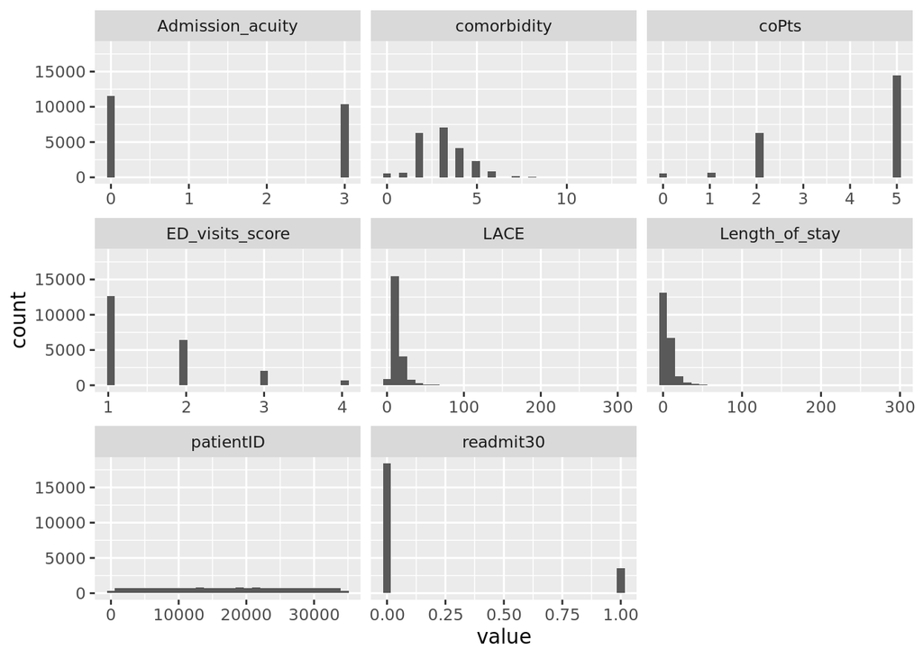

```r
ggplot(gather(LACE_pt), aes(x = value)) +
  geom_histogram() +
  facet_wrap(~key, scales = 'free_x')
```

```r
skim(LACE_pt)
```

Data summary

| Name | LACE_pt |
| --- | --- |
| Number of rows | 21904 |
| Number of columns | 8 |
| _______________________ |  |
| Column type frequency: |  |
| numeric | 8 |
| ________________________ |  |
| Group variables |  |

**Variable type: numeric**

| skim_variable | n_missing | complete_rate | mean | sd | p0 | p25 | p50 | p75 | p100 | hist |
| --- | --- | --- | --- | --- | --- | --- | --- | --- | --- | --- |
| patientID | 0 | 1 | 17265.98 | 9951.92 | 1 | 8703.25 | 17252 | 25868.25 | 34532 | ▇▇▇▇▇ |
| Length_of_stay | 0 | 1 | 7.07 | 9.67 | 1 | 2.00 | 4 | 8.00 | 297 | ▇▁▁▁▁ |
| Admission_acuity | 0 | 1 | 1.42 | 1.50 | 0 | 0.00 | 0 | 3.00 | 3 | ▇▁▁▁▇ |
| comorbidity | 0 | 1 | 3.14 | 1.32 | 0 | 2.00 | 3 | 4.00 | 13 | ▅▇▁▁▁ |
| coPts | 0 | 1 | 3.91 | 1.56 | 0 | 2.00 | 5 | 5.00 | 5 | ▁▃▁▁▇ |
| ED_visits_score | 0 | 1 | 1.58 | 0.79 | 1 | 1.00 | 1 | 2.00 | 4 | ▇▅▁▁▁ |
| LACE | 0 | 1 | 13.98 | 9.92 | 2 | 9.00 | 12 | 16.00 | 306 | ▇▁▁▁▁ |
| readmit30 | 0 | 1 | 0.16 | 0.37 | 0 | 0.00 | 0 | 0.00 | 1 | ▇▁▁▁▂ |

```r
summary(LACE_pt)
```

```
##    patientID     Length_of_stay    Admission_acuity  comorbidity
##  Min.   :    1   Min.   :  1.000   Min.   :0.00     Min.   : 0.00
##  1st Qu.: 8703   1st Qu.:  2.000   1st Qu.:0.00     1st Qu.: 2.00
##  Median :17252   Median :  4.000   Median :0.00     Median : 3.00
##  Mean   :17266   Mean   :  7.074   Mean   :1.42     Mean   : 3.14
##  3rd Qu.:25868   3rd Qu.:  8.000   3rd Qu.:3.00     3rd Qu.: 4.00
##  Max.   :34532   Max.   :297.000   Max.   :3.00     Max.   :13.00
##      coPts       ED_visits_score      LACE          readmit30
##  Min.   :0.000   Min.   :1.000   Min.   :  2.00   Min.   :0.0000
##  1st Qu.:2.000   1st Qu.:1.000   1st Qu.:  9.00   1st Qu.:0.0000
##  Median :5.000   Median :1.000   Median : 12.00   Median :0.0000
##  Mean   :3.907   Mean   :1.581   Mean   : 13.98   Mean   :0.1601
##  3rd Qu.:5.000   3rd Qu.:2.000   3rd Qu.: 16.00   3rd Qu.:0.0000
##  Max.   :5.000   Max.   :4.000   Max.   :306.00   Max.   :1.0000
```

No missing data, 21904 observations of 8 variables.

Factors in this dataset are: Admission_acuity, either 0 or 3 readmit30, either 0 or 1 ED_visits_score, 1, 2, 3, or 4 coPts, 0, 1, 2, or 5

and comorbidity can be argued either way, as either numeric or factor. Let’s treat it as factor moving forward.

# Data Wrangling

```r
# Retype the factors

LACE_pt$readmit30 <-factor(LACE_pt$readmit30,labels=c('no','yes'))
LACE_pt$Admission_acuity <- factor(LACE_pt$Admission_acuity)
LACE_pt$ED_visits_score <- factor(LACE_pt$ED_visits_score)
LACE_pt$coPts <- factor(LACE_pt$coPts)
LACE_pt$comorbidity <- factor(LACE_pt$comorbidity)

# Summarize data

summary(LACE_pt)
```

```
##    patientID     Length_of_stay    Admission_acuity  comorbidity   coPts
##  Min.   :    1   Min.   :  1.000   0:11539          3      :7022   0:  510
##  1st Qu.: 8703   1st Qu.:  2.000   3:10365          2      :6294   1:  630
##  Median :17252   Median :  4.000                    4      :4115   2: 6294
##  Mean   :17266   Mean   :  7.074                    5      :2302   5:14470
##  3rd Qu.:25868   3rd Qu.:  8.000                    6      : 808
##  Max.   :34532   Max.   :297.000                    1      : 630
##                                                     (Other): 733
##  ED_visits_score      LACE        readmit30
##  1:12674         Min.   :  2.00   no :18398
##  2: 6441         1st Qu.:  9.00   yes: 3506
##  3: 2086         Median : 12.00
##  4:  703         Mean   : 13.98
##                  3rd Qu.: 16.00
##                  Max.   :306.00
##
```

```r
skim(LACE_pt)
```

Data summary

| Name | LACE_pt |
| --- | --- |
| Number of rows | 21904 |
| Number of columns | 8 |
| _______________________ |  |
| Column type frequency: |  |
| factor | 5 |
| numeric | 3 |
| ________________________ |  |
| Group variables |  |

**Variable type: factor**

| skim_variable | n_missing | complete_rate | ordered | n_unique | top_counts |
| --- | --- | --- | --- | --- | --- |
| Admission_acuity | 0 | 1 | FALSE | 2 | 0: 11539, 3: 10365 |
| comorbidity | 0 | 1 | FALSE | 14 | 3: 7022, 2: 6294, 4: 4115, 5: 2302 |
| coPts | 0 | 1 | FALSE | 4 | 5: 14470, 2: 6294, 1: 630, 0: 510 |
| ED_visits_score | 0 | 1 | FALSE | 4 | 1: 12674, 2: 6441, 3: 2086, 4: 703 |
| readmit30 | 0 | 1 | FALSE | 2 | no: 18398, yes: 3506 |

**Variable type: numeric**

| skim_variable | n_missing | complete_rate | mean | sd | p0 | p25 | p50 | p75 | p100 | hist |
| --- | --- | --- | --- | --- | --- | --- | --- | --- | --- | --- |
| patientID | 0 | 1 | 17265.98 | 9951.92 | 1 | 8703.25 | 17252 | 25868.25 | 34532 | ▇▇▇▇▇ |
| Length_of_stay | 0 | 1 | 7.07 | 9.67 | 1 | 2.00 | 4 | 8.00 | 297 | ▇▁▁▁▁ |
| LACE | 0 | 1 | 13.98 | 9.92 | 2 | 9.00 | 12 | 16.00 | 306 | ▇▁▁▁▁ |

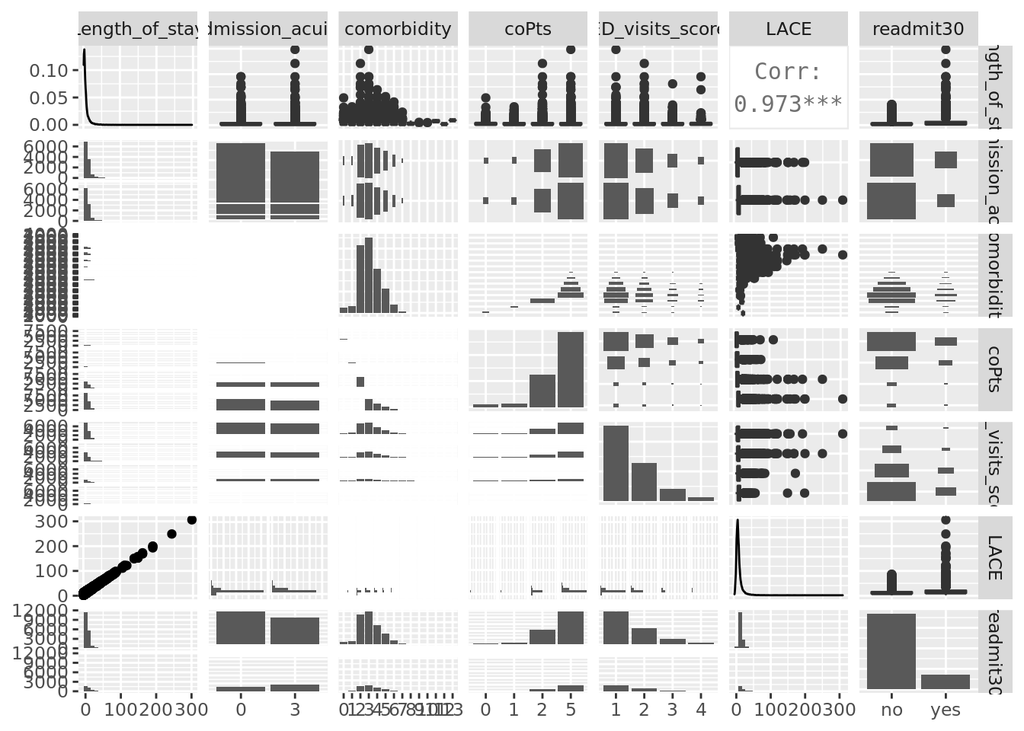

```r
# Look at every pairing

no.PtID <- LACE_pt[2:8]
ggpairs(no.PtID)
```

At a glance, nothing in the ggpairs indicates that any one variable is specifically predictive of readmission, or even that there’s high correlation between independent variables (L, coPts, and Admission_acuity). The full LACE score also doesn’t indicate it will be terribly predictive on its own, suggesting that we might be missing something huge here.

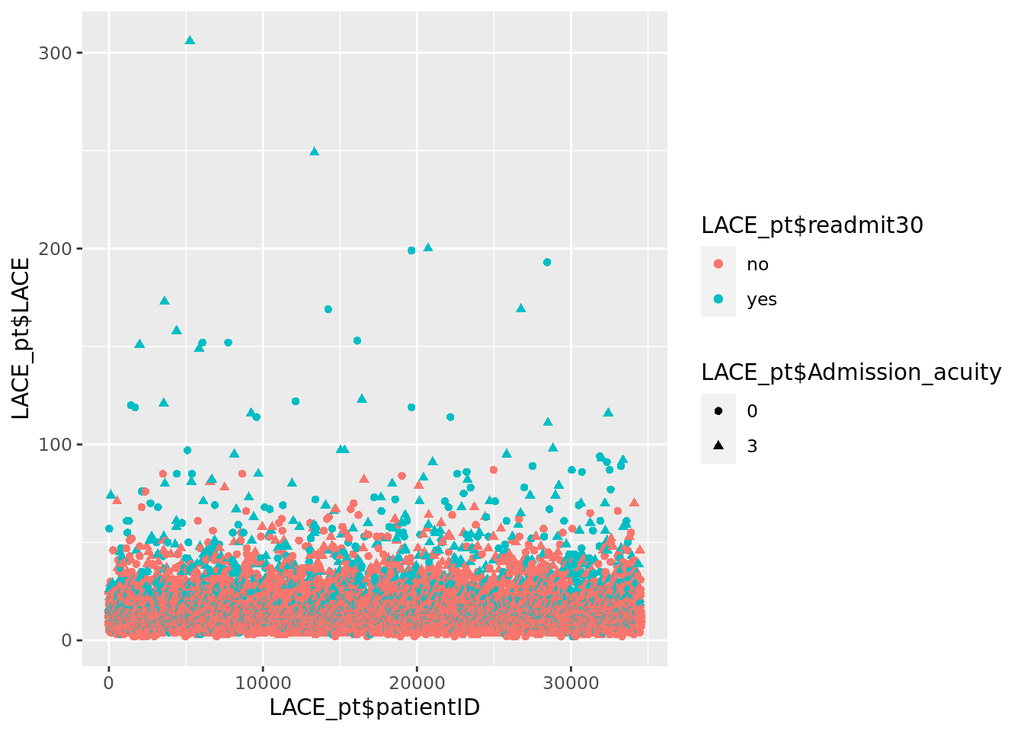

```r
qplot(x = LACE_pt$patientID, y = LACE_pt$LACE, col=LACE_pt$readmit30, shape = LACE_pt$Admission_acuity)
```

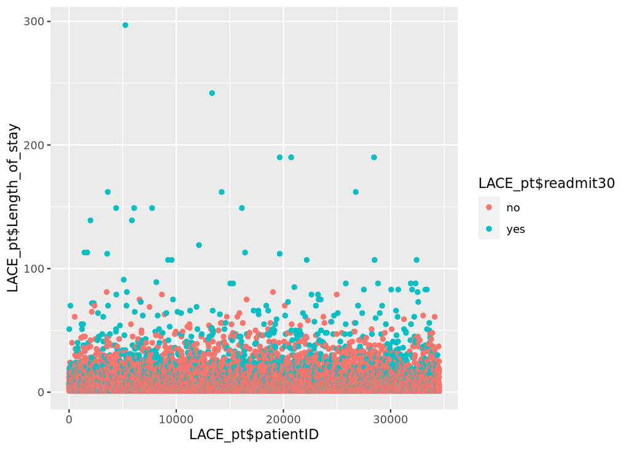

```r
qplot(x = LACE_pt$patientID, y = LACE_pt$Length_of_stay, col = LACE_pt$readmit30)
```

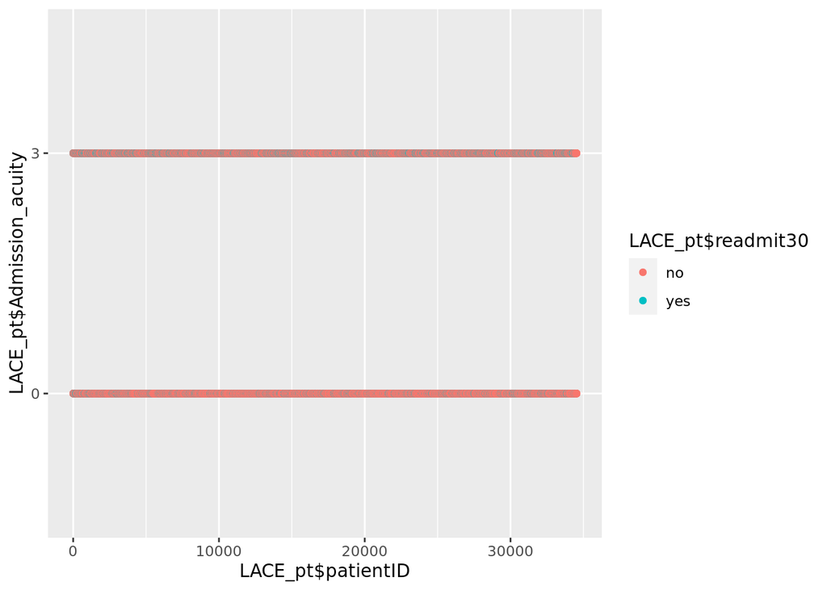

```r
qplot(x = LACE_pt$patientID, y = LACE_pt$Admission_acuity, col = LACE_pt$readmit30)
```

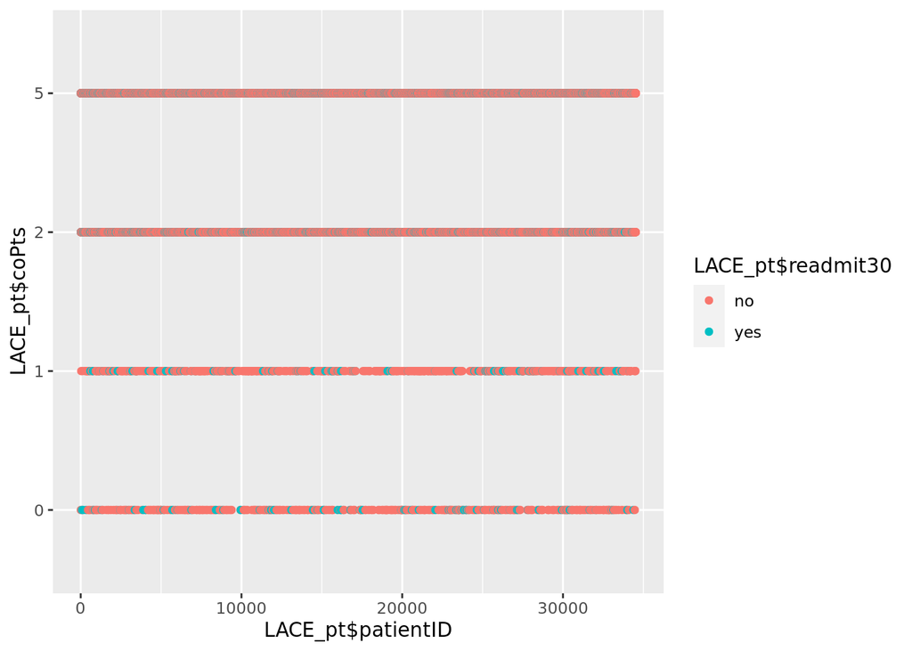

```r
qplot(x = LACE_pt$patientID, y = LACE_pt$coPts, col = LACE_pt$readmit30)
```

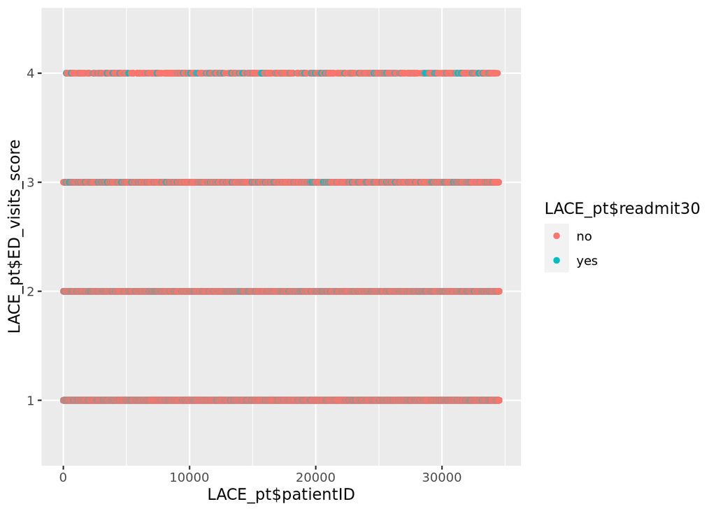

```r
qplot(x = LACE_pt$patientID, y = LACE_pt$ED_visits_score, col = LACE_pt$readmit30)
```

There doesn’t appear to be a nice separation of classes in any particular variable according to LACE score or any of the individual components.

I wanna test things after scaling the Length_of_stay because there is an outlier that looks like it could be pulling the data.

```r
LACE_pt.scaled <- LACE_pt %>%
  mutate(Length_of_stay = scale(Length_of_stay, center = TRUE))
```

# Create Training and Testing Datasets

Setting type for each of the clearly factor variables ensure they’re not treated as numeric in the model.

TECHNICALLY, we should also have a validation set, but in the interest of time and ease of explanation, will go with suggestions from assignment instructions of splitting into 2 partitions: training and testing.

```r
set.seed(111)

#grab indices of the dataset that represent 80% of the data
trainingIndices <- createDataPartition(y = LACE_pt$readmit30, p=.80,
                                       list=FALSE)

#show the first few training indices
trainingIndices[1:10]
```

```
##  [1]  1  2  4  5  6  7  9 11 13 14
```

```r
#select the rows
trainData <- LACE_pt[trainingIndices,]
#confirm the number of rows (should be 80)
nrow(trainData)
```

```
## [1] 17524
```

```r
#build our test set using the R-indexing
#using the "-" operator
testData <- LACE_pt[-trainingIndices,]

#confirm the number of rows
nrow(testData)
```

```
## [1] 4380
```

Secondary set of training/testing data - specifically for scaled.

```r
trainData.scaled <- LACE_pt.scaled[trainingIndices,]

testData.scaled <- LACE_pt.scaled[-trainingIndices,]

nrow(testData.scaled)
```

```
## [1] 4380
```

```r
nrow(trainData.scaled)
```

```
## [1] 17524
```

Confirm partitioned data are as expected.

```r
# Expected rows:

.8 * nrow(LACE_pt)
```

```
## [1] 17523.2
```

```r
# Confirm:

nrow(LACE_pt) == nrow(testData) + nrow(trainData)
```

```
## [1] TRUE
```

```r
skim(testData)
```

Data summary

| Name | testData |
| --- | --- |
| Number of rows | 4380 |
| Number of columns | 8 |
| _______________________ |  |
| Column type frequency: |  |
| factor | 5 |
| numeric | 3 |
| ________________________ |  |
| Group variables |  |

**Variable type: factor**

| skim_variable | n_missing | complete_rate | ordered | n_unique | top_counts |
| --- | --- | --- | --- | --- | --- |
| Admission_acuity | 0 | 1 | FALSE | 2 | 0: 2301, 3: 2079 |
| comorbidity | 0 | 1 | FALSE | 13 | 3: 1425, 2: 1279, 4: 783, 5: 452 |
| coPts | 0 | 1 | FALSE | 4 | 5: 2870, 2: 1279, 1: 123, 0: 108 |
| ED_visits_score | 0 | 1 | FALSE | 4 | 1: 2503, 2: 1311, 3: 428, 4: 138 |
| readmit30 | 0 | 1 | FALSE | 2 | no: 3679, yes: 701 |

**Variable type: numeric**

| skim_variable | n_missing | complete_rate | mean | sd | p0 | p25 | p50 | p75 | p100 | hist |
| --- | --- | --- | --- | --- | --- | --- | --- | --- | --- | --- |
| patientID | 0 | 1 | 17219.47 | 9975.22 | 3 | 8533.75 | 17110.5 | 25942.75 | 34532 | ▇▇▇▇▇ |
| Length_of_stay | 0 | 1 | 7.35 | 11.25 | 1 | 2.00 | 4.0 | 8.00 | 297 | ▇▁▁▁▁ |
| LACE | 0 | 1 | 14.25 | 11.52 | 2 | 9.00 | 12.0 | 16.00 | 306 | ▇▁▁▁▁ |

```r
skim(trainData)
```

Data summary

| Name | trainData |
| --- | --- |
| Number of rows | 17524 |
| Number of columns | 8 |
| _______________________ |  |
| Column type frequency: |  |
| factor | 5 |
| numeric | 3 |
| ________________________ |  |
| Group variables |  |

**Variable type: factor**

| skim_variable | n_missing | complete_rate | ordered | n_unique | top_counts |
| --- | --- | --- | --- | --- | --- |
| Admission_acuity | 0 | 1 | FALSE | 2 | 0: 9238, 3: 8286 |
| comorbidity | 0 | 1 | FALSE | 13 | 3: 5597, 2: 5015, 4: 3332, 5: 1850 |
| coPts | 0 | 1 | FALSE | 4 | 5: 11600, 2: 5015, 1: 507, 0: 402 |
| ED_visits_score | 0 | 1 | FALSE | 4 | 1: 10171, 2: 5130, 3: 1658, 4: 565 |
| readmit30 | 0 | 1 | FALSE | 2 | no: 14719, yes: 2805 |

**Variable type: numeric**

| skim_variable | n_missing | complete_rate | mean | sd | p0 | p25 | p50 | p75 | p100 | hist |
| --- | --- | --- | --- | --- | --- | --- | --- | --- | --- | --- |
| patientID | 0 | 1 | 17277.60 | 9946.34 | 1 | 8752.75 | 17296.5 | 25853.75 | 34531 | ▇▇▇▇▇ |
| Length_of_stay | 0 | 1 | 7.00 | 9.23 | 1 | 2.00 | 4.0 | 8.00 | 242 | ▇▁▁▁▁ |
| LACE | 0 | 1 | 13.91 | 9.48 | 2 | 9.00 | 12.0 | 16.00 | 249 | ▇▁▁▁▁ |

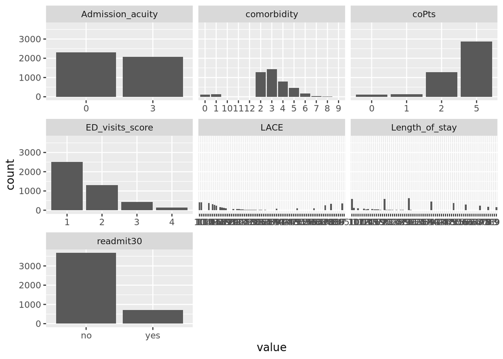

```r
ggplot(gather(testData[2:8]), aes(x = value)) +
  geom_histogram(stat = 'count') +
  facet_wrap(~key, scales = 'free_x')
```

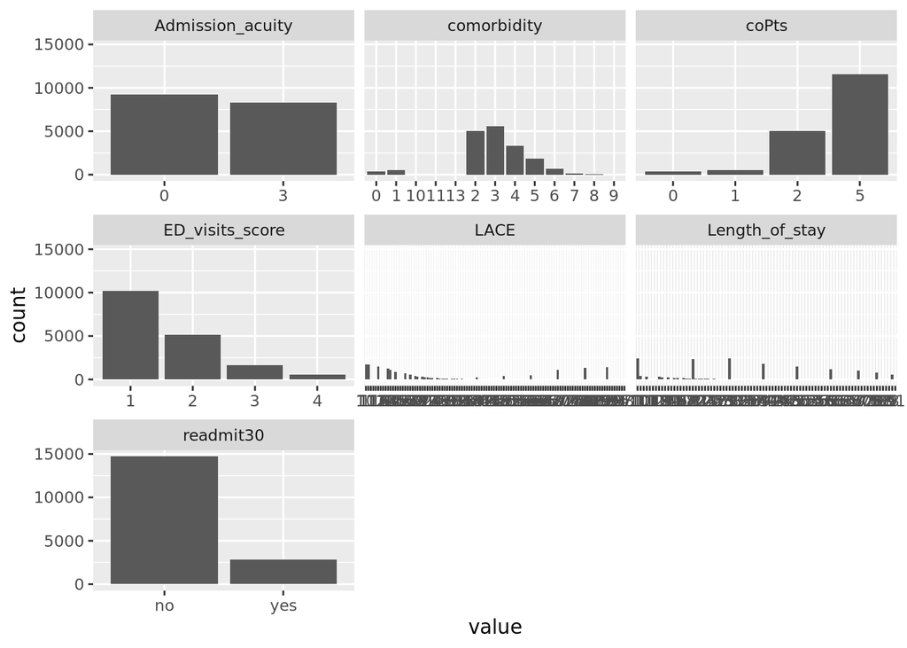

```r
ggplot(gather(trainData[2:8]), aes(x = value)) +
  geom_histogram(stat = 'count') +
  facet_wrap(~key, scales = 'free_x')
```

The distributions of the different elements generally look similar in the data partitions, so it’s ok to proceed with modeling.

# Linear Model

```r
#show variable names in analytic data.frame
colnames(trainData)
```

```
## [1] "patientID"        "Length_of_stay"   "Admission_acuity" "comorbidity"
## [5] "coPts"            "ED_visits_score"  "LACE"             "readmit30"
```

```r
#run a logistic regression model using our LACE components

LACEModel <- glm(readmit30 ~ Length_of_stay + Admission_acuity + coPts + ED_visits_score, data= trainData, family=binomial(link = 'logit'))
summary(LACEModel)
```

```
##
## Call:
## glm(formula = readmit30 ~ Length_of_stay + Admission_acuity +
##     coPts + ED_visits_score, family = binomial(link = "logit"),
##     data = trainData)
##
## Deviance Residuals:
##     Min       1Q   Median       3Q      Max
## -2.0893  -0.6169  -0.4944  -0.4266   2.3035
##
## Coefficients:
##                    Estimate Std. Error z value Pr(>|z|)
## (Intercept)       -2.466714   0.144716 -17.045   <2e-16 ***
## Length_of_stay     0.051021   0.002173  23.477   <2e-16 ***
## Admission_acuity3  0.689742   0.043250  15.948   <2e-16 ***
## coPts1            -0.164306   0.191659  -0.857   0.3913
## coPts2            -0.100865   0.145655  -0.692   0.4886
## coPts5             0.023286   0.142201   0.164   0.8699
## ED_visits_score2   0.114346   0.047870   2.389   0.0169 *
## ED_visits_score3   0.088954   0.073973   1.203   0.2292
## ED_visits_score4   0.300998   0.113674   2.648   0.0081 **
## ---
## Signif. codes:  0 '***' 0.001 '**' 0.01 '*' 0.05 '.' 0.1 ' ' 1
##
## (Dispersion parameter for binomial family taken to be 1)
##
##     Null deviance: 15413  on 17523  degrees of freedom
## Residual deviance: 14534  on 17515  degrees of freedom
## AIC: 14552
##
## Number of Fisher Scoring iterations: 4
```

And the scaled version.

```r
LACEModel.scaled <- glm(readmit30 ~ Length_of_stay + Admission_acuity + coPts + ED_visits_score, data = trainData.scaled, family = binomial(link = 'logit'))

summary(LACEModel.scaled)
```

```
##
## Call:
## glm(formula = readmit30 ~ Length_of_stay + Admission_acuity +
##     coPts + ED_visits_score, family = binomial(link = "logit"),
##     data = trainData.scaled)
##
## Deviance Residuals:
##     Min       1Q   Median       3Q      Max
## -2.0893  -0.6169  -0.4944  -0.4266   2.3035
##
## Coefficients:
##                   Estimate Std. Error z value Pr(>|z|)
## (Intercept)       -2.10578    0.14329 -14.696   <2e-16 ***
## Length_of_stay     0.49314    0.02100  23.477   <2e-16 ***
## Admission_acuity3  0.68974    0.04325  15.948   <2e-16 ***
## coPts1            -0.16431    0.19166  -0.857   0.3913
## coPts2            -0.10086    0.14566  -0.692   0.4886
## coPts5             0.02329    0.14220   0.164   0.8699
## ED_visits_score2   0.11435    0.04787   2.389   0.0169 *
## ED_visits_score3   0.08895    0.07397   1.203   0.2292
## ED_visits_score4   0.30100    0.11367   2.648   0.0081 **
## ---
## Signif. codes:  0 '***' 0.001 '**' 0.01 '*' 0.05 '.' 0.1 ' ' 1
##
## (Dispersion parameter for binomial family taken to be 1)
##
##     Null deviance: 15413  on 17523  degrees of freedom
## Residual deviance: 14534  on 17515  degrees of freedom
## AIC: 14552
##
## Number of Fisher Scoring iterations: 4
```

Model results don’t appear that much different between “raw” version and scaled version.

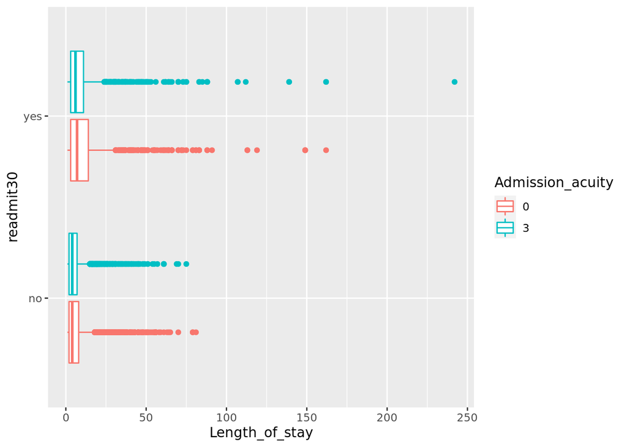

```r
ggplot(trainData, aes(y = readmit30, x = Length_of_stay, color = Admission_acuity)) +
  geom_boxplot()
```

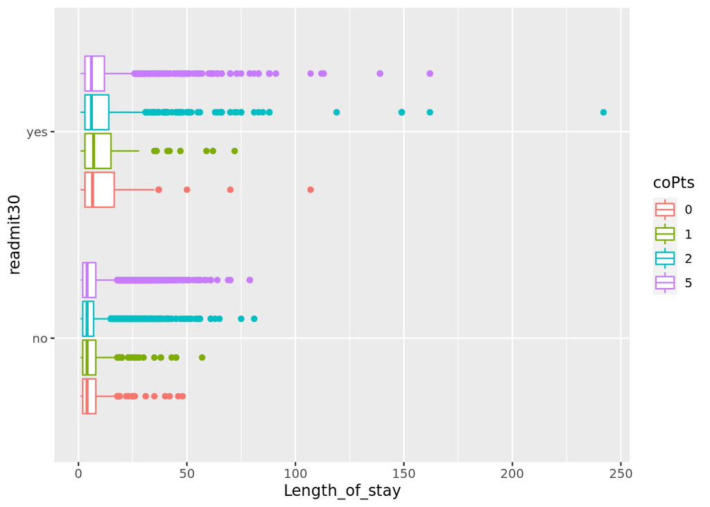

```r
ggplot(trainData, aes(y = readmit30, x = Length_of_stay, color = coPts)) +
  geom_boxplot()
```

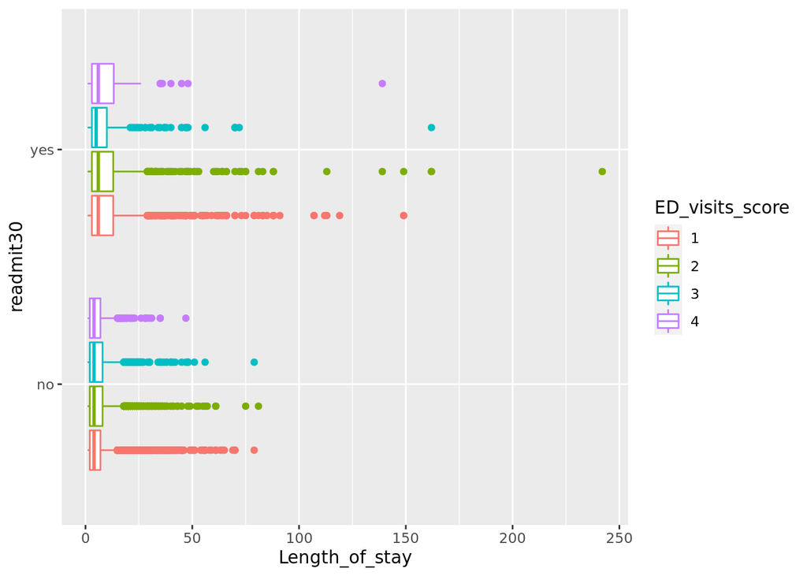

```r
ggplot(trainData, aes(y = readmit30, x = Length_of_stay, color = ED_visits_score)) +
  geom_boxplot()
```

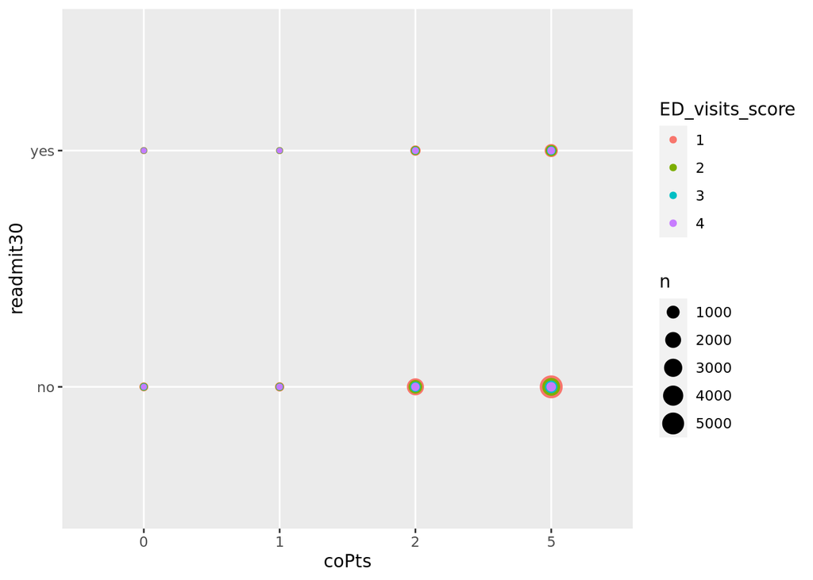

```r
ggplot(trainData, aes(y = readmit30, x = coPts, color = ED_visits_score)) +
  geom_count()
```

There really is poor deliniation between our readmit classes and the 4 variables.

```r
#Summarize the model
tidy(LACEModel)
```

```
## # A tibble: 9 x 5
##   term              estimate std.error statistic   p.value
##   <chr>                <dbl>     <dbl>     <dbl>     <dbl>
## 1 (Intercept)        -2.47     0.145     -17.0   3.79e- 65
## 2 Length_of_stay      0.0510   0.00217    23.5   6.94e-122
## 3 Admission_acuity3   0.690    0.0432     15.9   2.95e- 57
## 4 coPts1             -0.164    0.192      -0.857 3.91e-  1
## 5 coPts2             -0.101    0.146      -0.692 4.89e-  1
## 6 coPts5              0.0233   0.142       0.164 8.70e-  1
## 7 ED_visits_score2    0.114    0.0479      2.39  1.69e-  2
## 8 ED_visits_score3    0.0890   0.0740      1.20  2.29e-  1
## 9 ED_visits_score4    0.301    0.114       2.65  8.10e-  3
```

```r
tidy(LACEModel.scaled)
```

```
## # A tibble: 9 x 5
##   term              estimate std.error statistic   p.value
##   <chr>                <dbl>     <dbl>     <dbl>     <dbl>
## 1 (Intercept)        -2.11      0.143    -14.7   6.82e- 49
## 2 Length_of_stay      0.493     0.0210    23.5   6.94e-122
## 3 Admission_acuity3   0.690     0.0432    15.9   2.95e- 57
## 4 coPts1             -0.164     0.192     -0.857 3.91e-  1
## 5 coPts2             -0.101     0.146     -0.692 4.89e-  1
## 6 coPts5              0.0233    0.142      0.164 8.70e-  1
## 7 ED_visits_score2    0.114     0.0479     2.39  1.69e-  2
## 8 ED_visits_score3    0.0890    0.0740     1.20  2.29e-  1
## 9 ED_visits_score4    0.301     0.114      2.65  8.10e-  3
```

```r
#grab coefficients themselves
coef(LACEModel)
```

```
##       (Intercept)    Length_of_stay Admission_acuity3            coPts1
##       -2.46671367        0.05102051        0.68974232       -0.16430592
##            coPts2            coPts5  ED_visits_score2  ED_visits_score3
##       -0.10086498        0.02328551        0.11434590        0.08895400
##  ED_visits_score4
##        0.30099818
```

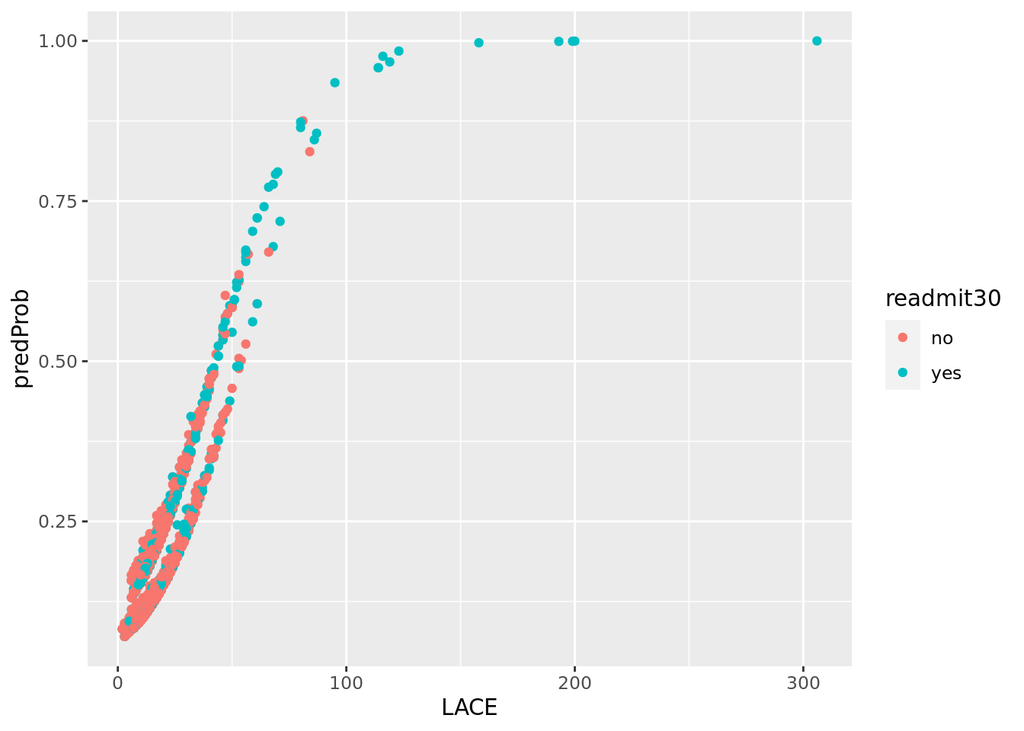

```r
modelPredictedProbabilities <- predict(LACEModel, newdata=testData, type = "response")

##add the modelPredictedProbabilities as a column in testData
testData <- data.frame(testData, predProb=modelPredictedProbabilities)


testData %>% ggplot(aes(x=LACE, y=predProb, color=readmit30)) + geom_point()
```

Again, no clear class separation.

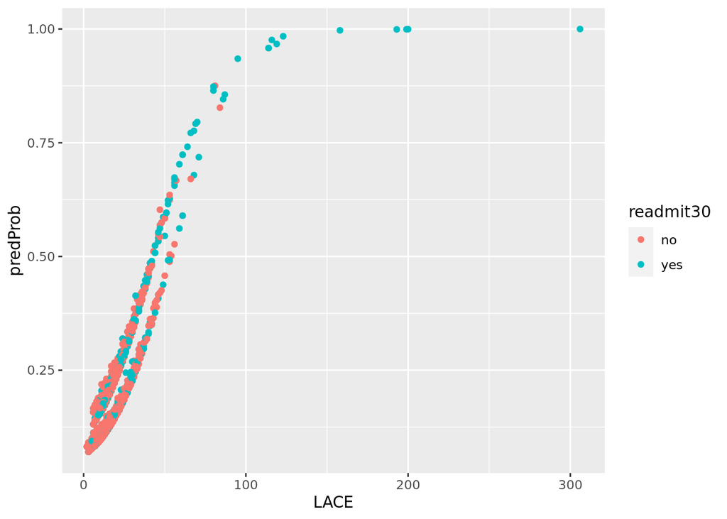

```r
modelPredictedProbabilities.scaled <- predict(LACEModel.scaled, newdata=testData.scaled, type = "response")

##add the modelPredictedProbabilities as a column in testData
testData.scaled <- data.frame(testData.scaled, predProb=modelPredictedProbabilities.scaled)


testData.scaled %>% ggplot(aes(x=LACE, y=predProb, color=readmit30)) + geom_point()
```

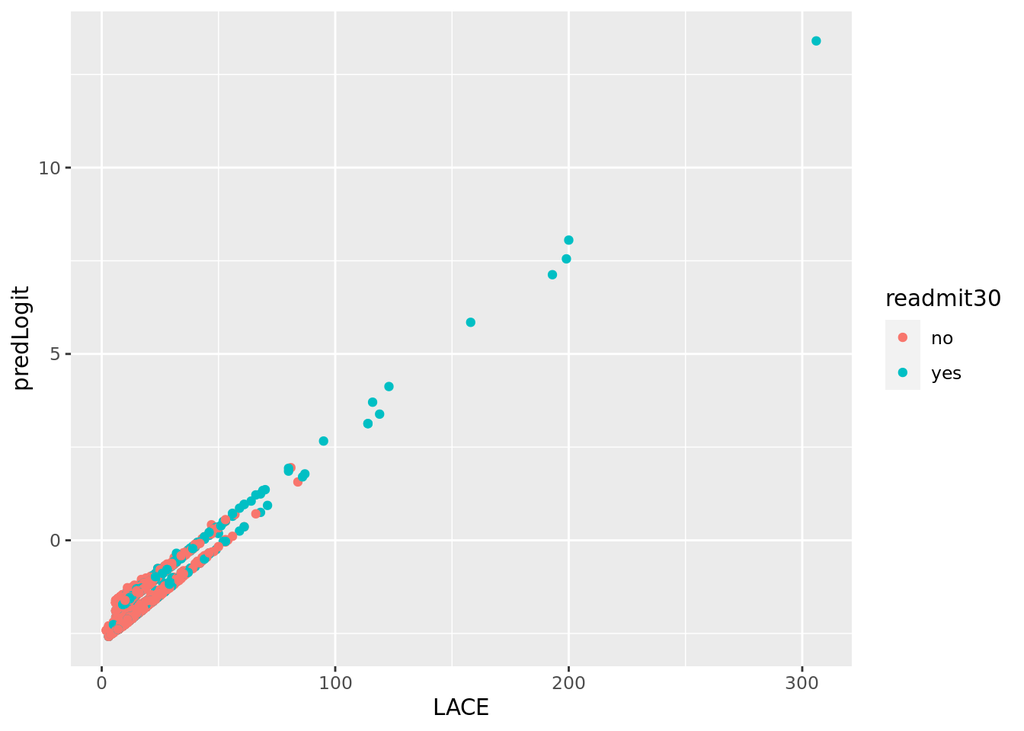

```r
#predict the logit instead for our testData
modelPredictedLogOddsRatio <- predict(LACEModel,newdata = testData)

#add as another column in our table
testDataPred <- data.frame(testData, predLogit = modelPredictedLogOddsRatio)

#plot the age versus logit (coloring by gender)
testDataPred %>% ggplot(aes(x=LACE, y=predLogit, color=readmit30)) + geom_point()
```

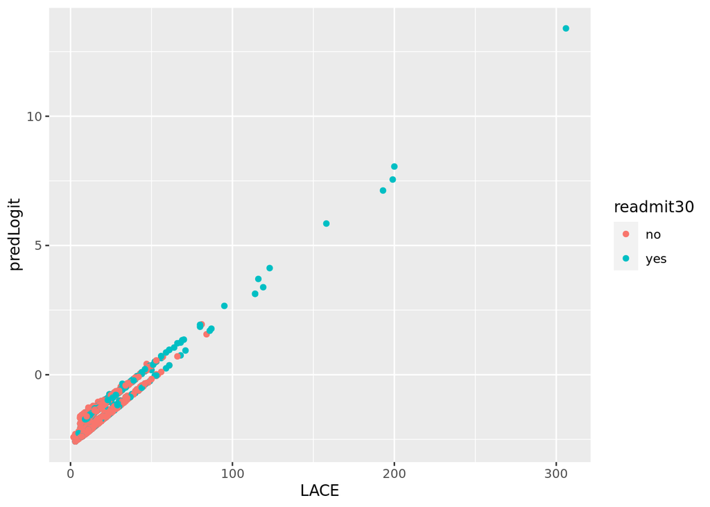

```r
#predict the logit instead for our testData
modelPredictedLogOddsRatio.scaled <- predict(LACEModel.scaled,newdata = testData.scaled)

#add as another column in our table
testDataPred.scaled <- data.frame(testData.scaled, predLogit = modelPredictedLogOddsRatio.scaled)

#plot the age versus logit (coloring by gender)
testDataPred.scaled %>% ggplot(aes(x=LACE, y=predLogit, color=readmit30)) + geom_point()
```

```r
#transform the logit to the predictedOdds ratio
modelPredictedOddsRatio <- exp(modelPredictedLogOddsRatio)
modelPredictedOddsRatio[1:10]
```

```
##          1          2          3          4          5          6          7
## 0.11797234 0.24745110 0.09051748 0.11349225 0.12414754 0.20957139 0.10419870
##          8          9         10
## 0.10248265 0.12937130 0.10514308
```

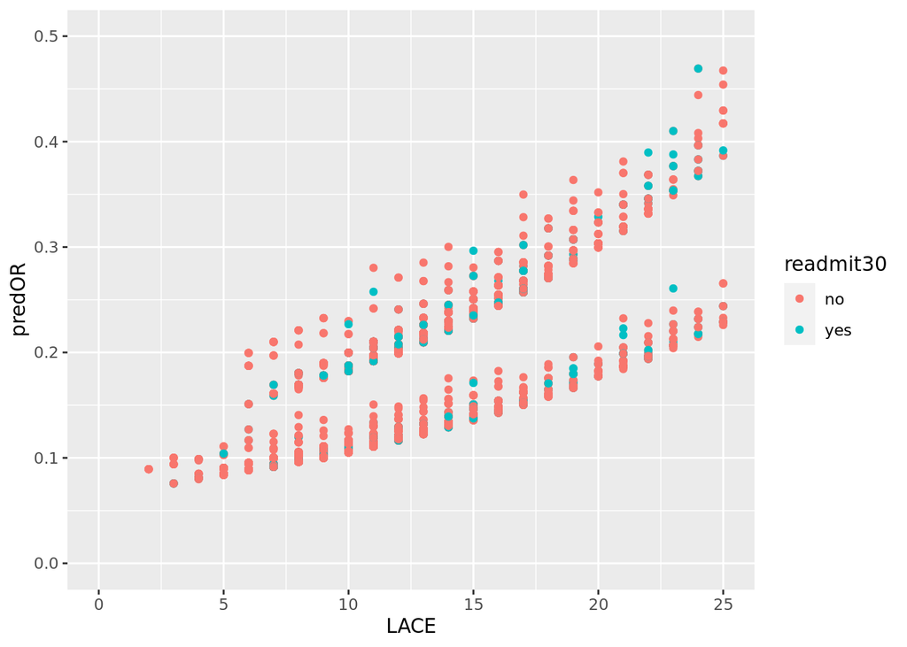

```r
#add as column in our table
testDataPred <- data.frame(testDataPred, predOR = modelPredictedOddsRatio)


testDataPred %>% ggplot(aes(x=LACE, y=predOR, col=readmit30)) + geom_point() + xlim(0,25) + ylim(0,0.5)
```

```r
exp(coef(LACEModel))
```

```
##       (Intercept)    Length_of_stay Admission_acuity3            coPts1
##        0.08486329        1.05234447        1.99320186        0.84848241
##            coPts2            coPts5  ED_visits_score2  ED_visits_score3
##        0.90405509        1.02355874        1.12113986        1.09303037
##  ED_visits_score4
##        1.35120688
```

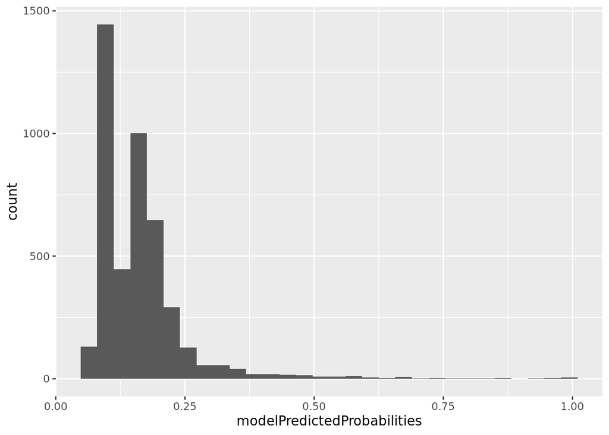

```r
modelPredictedProbabilities %>% data.frame() %>% ggplot(aes(x=modelPredictedProbabilities)) + geom_histogram()
```

```r
modelPredictions <- ifelse(modelPredictedProbabilities < 0.13, "no", "yes")
modelPredictions[1:10]
```

```
##     1     2     3     4     5     6     7     8     9    10
##  "no" "yes"  "no"  "no"  "no" "yes"  "no"  "no"  "no"  "no"
```

```r
modelPredictions.scaled <- ifelse(modelPredictedProbabilities.scaled < 0.13, "no", "yes")
modelPredictions.scaled[1:10]
```

```
##     1     2     3     4     5     6     7     8     9    10
##  "no" "yes"  "no"  "no"  "no" "yes"  "no"  "no"  "no"  "no"
```

```r
truthPredict <- table(testData$readmit30, modelPredictions)
truthPredict
```

```
##      modelPredictions
##         no  yes
##   no  1676 2003
##   yes  170  531
```

```r
totalCases <- sum(truthPredict)
misclassified <- truthPredict[1,2] + truthPredict[2,1]
misclassified
```

```
## [1] 2173
```

```r
accuracy <- (totalCases - misclassified) / totalCases
accuracy
```

```
## [1] 0.5038813
```

```r
caret::confusionMatrix(testData$readmit30, factor(modelPredictions), positive = "yes")
```

```
## Confusion Matrix and Statistics
##
##           Reference
## Prediction   no  yes
##        no  1676 2003
##        yes  170  531
##
##                Accuracy : 0.5039
##                  95% CI : (0.489, 0.5188)
##     No Information Rate : 0.5785
##     P-Value [Acc > NIR] : 1
##
##                   Kappa : 0.1035
##  Mcnemar's Test P-Value : <2e-16
##
##             Sensitivity : 0.2096
##             Specificity : 0.9079
##          Pos Pred Value : 0.7575
##          Neg Pred Value : 0.4556
##              Prevalence : 0.5785
##          Detection Rate : 0.1212
##    Detection Prevalence : 0.1600
##       Balanced Accuracy : 0.5587
##
##        'Positive' Class : yes
##
```

```r
confusionMatrix(testData.scaled$readmit30, factor(modelPredictions.scaled), positive = "yes")
```

```
## Confusion Matrix and Statistics
##
##           Reference
## Prediction   no  yes
##        no  1676 2003
##        yes  170  531
##
##                Accuracy : 0.5039
##                  95% CI : (0.489, 0.5188)
##     No Information Rate : 0.5785
##     P-Value [Acc > NIR] : 1
##
##                   Kappa : 0.1035
##  Mcnemar's Test P-Value : <2e-16
##
##             Sensitivity : 0.2096
##             Specificity : 0.9079
##          Pos Pred Value : 0.7575
##          Neg Pred Value : 0.4556
##              Prevalence : 0.5785
##          Detection Rate : 0.1212
##    Detection Prevalence : 0.1600
##       Balanced Accuracy : 0.5587
##
##        'Positive' Class : yes
##
```

The scaled model does not appear to perform better than the non-scaled model. Sensitivity is very low, while specificity is through the roof; I suspect this is because of the overrepresentation of negative outcomes and lack of clear class distinction.

```r
truth <- factor(testData$readmit30, levels=c("yes","no"))
#seq() function allows us to make a sequence of cutoffs
cutoffs <- seq(from=0.01,to=1, by = 0.01)
cutoffs
```

```
##   [1] 0.01 0.02 0.03 0.04 0.05 0.06 0.07 0.08 0.09 0.10 0.11 0.12 0.13 0.14 0.15
##  [16] 0.16 0.17 0.18 0.19 0.20 0.21 0.22 0.23 0.24 0.25 0.26 0.27 0.28 0.29 0.30
##  [31] 0.31 0.32 0.33 0.34 0.35 0.36 0.37 0.38 0.39 0.40 0.41 0.42 0.43 0.44 0.45
##  [46] 0.46 0.47 0.48 0.49 0.50 0.51 0.52 0.53 0.54 0.55 0.56 0.57 0.58 0.59 0.60
##  [61] 0.61 0.62 0.63 0.64 0.65 0.66 0.67 0.68 0.69 0.70 0.71 0.72 0.73 0.74 0.75
##  [76] 0.76 0.77 0.78 0.79 0.80 0.81 0.82 0.83 0.84 0.85 0.86 0.87 0.88 0.89 0.90
##  [91] 0.91 0.92 0.93 0.94 0.95 0.96 0.97 0.98 0.99 1.00
```

```r
# this function will produce a confusion matrix
# for a particular cutoff
run_cutoff <- function(cutoff){
  #Do thresholding with cutoff
  predictions <- ifelse(modelPredictedProbabilities < cutoff, "no", "yes")
  #run confusion matrix on predictions
  caret::confusionMatrix(
          factor(predictions, levels=c("yes", "no")),
                  truth,
                  positive="yes")
  }
```

```r
#run our function on all of our cutoffs
#the output is a list of confusion matrices
confusion_matrices <- lapply(cutoffs, run_cutoff)

#get the sensitivity out of the list of confusion matrices
sensitivities <- lapply(confusion_matrices, function(x){return(x$byClass["Sensitivity"])})

#get the sensitivity out of the list of confusion matrices
specificities <- lapply(confusion_matrices, function(x){return(x$byClass["Specificity"])})

#make sensitivities and specificities into vectors
sensitivities <- unlist(sensitivities)
specificities <- unlist(specificities)

#produce a data frame with all of the cutoffs
cutoff_frame <- data.frame(cutoff=cutoffs, sensitivity =sensitivities, specificity = specificities)
cutoff_frame
```

```
##     cutoff sensitivity specificity
## 1     0.01 1.000000000  0.00000000
## 2     0.02 1.000000000  0.00000000
## 3     0.03 1.000000000  0.00000000
## 4     0.04 1.000000000  0.00000000
## 5     0.05 1.000000000  0.00000000
## 6     0.06 1.000000000  0.00000000
## 7     0.07 1.000000000  0.00000000
## 8     0.08 0.990014265  0.03370481
## 9     0.09 0.940085592  0.14541995
## 10    0.10 0.881597718  0.28187007
## 11    0.11 0.831669044  0.37075292
## 12    0.12 0.787446505  0.42375646
## 13    0.13 0.757489301  0.45555858
## 14    0.14 0.726105563  0.49062245
```

[output cut: 86 more lines]

Simplifying the linear model to use only a couple of variables (the most significant found above):

```r
LACEModelSimple <- glm(readmit30 ~ Length_of_stay + Admission_acuity, data = trainData, family = "binomial")

summary(LACEModelSimple)
```

```
##
## Call:
## glm(formula = readmit30 ~ Length_of_stay + Admission_acuity,
##     family = "binomial", data = trainData)
##
## Deviance Residuals:
##     Min       1Q   Median       3Q      Max
## -2.0931  -0.6099  -0.4869  -0.4316   2.2209
##
## Coefficients:
##                    Estimate Std. Error z value Pr(>|z|)
## (Intercept)       -2.428314   0.038662  -62.81   <2e-16 ***
## Length_of_stay     0.050824   0.002172   23.40   <2e-16 ***
## Admission_acuity3  0.688398   0.043220   15.93   <2e-16 ***
## ---
## Signif. codes:  0 '***' 0.001 '**' 0.01 '*' 0.05 '.' 0.1 ' ' 1
##
## (Dispersion parameter for binomial family taken to be 1)
##
##     Null deviance: 15413  on 17523  degrees of freedom
## Residual deviance: 14553  on 17521  degrees of freedom
## AIC: 14559
##
## Number of Fisher Scoring iterations: 4
```

```r
tidy(LACEModelSimple)
```

```
## # A tibble: 3 x 5
##   term              estimate std.error statistic   p.value
##   <chr>                <dbl>     <dbl>     <dbl>     <dbl>
## 1 (Intercept)        -2.43     0.0387      -62.8 0.
## 2 Length_of_stay      0.0508   0.00217      23.4 3.95e-121
## 3 Admission_acuity3   0.688    0.0432       15.9 4.06e- 57
```

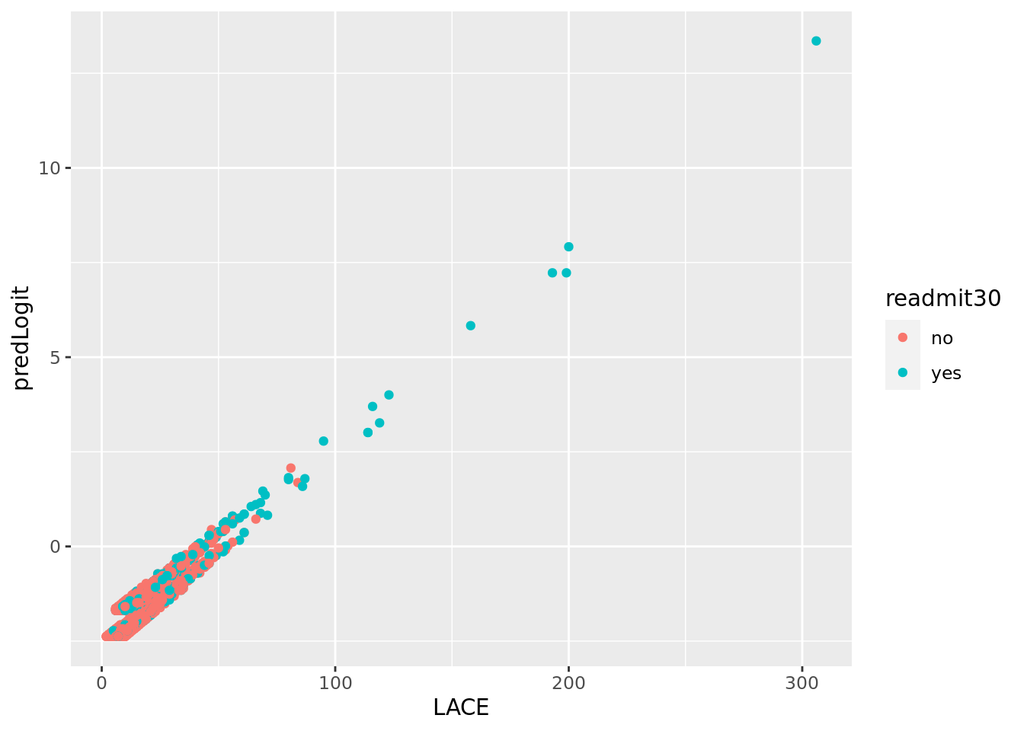

```r
#predict the SIMPLE logit instead for our testData
simplemodelPredictedLogOddsRatio <- predict(LACEModelSimple,newdata = testData)

#add as another column in our table
testDataPredsimple <- data.frame(testData, predLogit = simplemodelPredictedLogOddsRatio)

#plot the age versus logit (coloring by gender)
testDataPredsimple %>% ggplot(aes(x=LACE, y=predLogit, color=readmit30)) + geom_point()
```

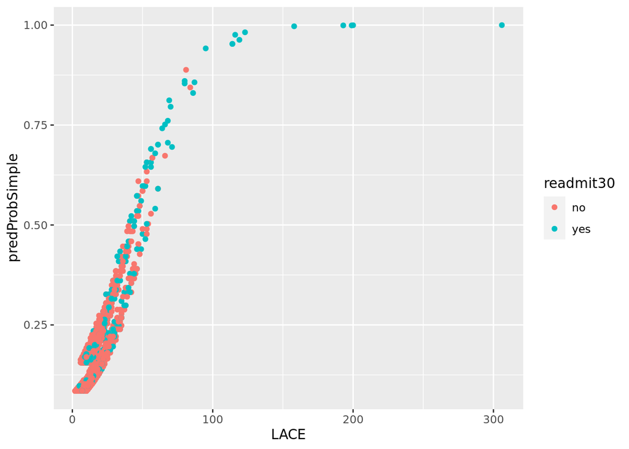

```r
simplemodelPredictedProbabilities <- predict(LACEModelSimple, newdata=testData, type = "response")

testData <- data.frame(testData, predProbSimple=simplemodelPredictedProbabilities)

testData %>%
  ggplot(aes(x = LACE, y = predProbSimple, color = readmit30)) +
  geom_point()
```

```r
simplemodelPredictions <- ifelse(simplemodelPredictedProbabilities < 0.13, "no", "yes")

simpletruthPredict <- table(testData$readmit30, simplemodelPredictions)
simpletruthPredict
```

```
##      simplemodelPredictions
##         no  yes
##   no  1698 1981
##   yes  174  527
```

```r
caret::confusionMatrix(testData$readmit30, factor(simplemodelPredictions), positive = "yes")
```

```
## Confusion Matrix and Statistics
##
##           Reference
## Prediction   no  yes
##        no  1698 1981
##        yes  174  527
##
##                Accuracy : 0.508
##                  95% CI : (0.4931, 0.5229)
##     No Information Rate : 0.5726
##     P-Value [Acc > NIR] : 1
##
##                   Kappa : 0.1044
##  Mcnemar's Test P-Value : <2e-16
##
##             Sensitivity : 0.2101
##             Specificity : 0.9071
##          Pos Pred Value : 0.7518
##          Neg Pred Value : 0.4615
##              Prevalence : 0.5726
##          Detection Rate : 0.1203
##    Detection Prevalence : 0.1600
##       Balanced Accuracy : 0.5586
##
##        'Positive' Class : yes
##
```

Simplified performs no better.

# Random Forest

I want a dataset that only has the data we’re going to use for the models in it.

```r
workingtrainData <- LACE_pt[trainingIndices,] %>%
  select(2, 3, 5, 6, 8)

workingtestData <- LACE_pt[-trainingIndices,] %>%
  select(2, 3, 5, 6, 8)
```

```r
set.seed(1701)

rf.LACE <- randomForest(readmit30 ~ ., data = workingtrainData, mtry = 4, importance = TRUE, ntree = 10)

rf.LACE
```

```
##
## Call:
##  randomForest(formula = readmit30 ~ ., data = workingtrainData,      mtry = 4, importance = TRUE, ntree = 10)
##                Type of random forest: classification
##                      Number of trees: 10
## No. of variables tried at each split: 4
##
##         OOB estimate of  error rate: 16.65%
## Confusion matrix:
##        no yes class.error
## no  14261 305  0.02093917
## yes  2584 204  0.92682927
```

```r
summary(rf.LACE)
```

```
##                 Length Class  Mode
## call                6  -none- call
## type                1  -none- character
## predicted       17524  factor numeric
## err.rate           30  -none- numeric
## confusion           6  -none- numeric
## votes           35048  matrix numeric
## oob.times       17524  -none- numeric
## classes             2  -none- character
## importance         16  -none- numeric
## importanceSD       12  -none- numeric
## localImportance     0  -none- NULL
## proximity           0  -none- NULL
## ntree               1  -none- numeric
## mtry                1  -none- numeric
## forest             14  -none- list
## y               17524  factor numeric
## test                0  -none- NULL
## inbag               0  -none- NULL
## terms               3  terms  call
```

```r
workingtestData <- mutate(workingtestData, rf.predictLACE = predict(rf.LACE, workingtestData, type = 'response'))

rf.table <- table(workingtestData$readmit30, workingtestData$rf.predictLACE)

rf.table
```

```
##
##         no  yes
##   no  3605   74
##   yes  637   64
```

```r
rf.misclassified <- rf.table[1,2] + rf.table[2,1]
rf.misclassified
```

```
## [1] 711
```

```r
rf.accuracy <- (nrow(workingtestData) - rf.misclassified) / nrow(workingtestData)
rf.accuracy
```

```
## [1] 0.8376712
```

```r
rf.conf <- confusionMatrix(workingtestData$readmit30, workingtestData$rf.predictLACE, positive = 'yes')

rf.conf
```

```
## Confusion Matrix and Statistics
##
##           Reference
## Prediction   no  yes
##        no  3605   74
##        yes  637   64
##
##                Accuracy : 0.8377
##                  95% CI : (0.8264, 0.8485)
##     No Information Rate : 0.9685
##     P-Value [Acc > NIR] : 1
##
##                   Kappa : 0.1055
##  Mcnemar's Test P-Value : <2e-16
##
##             Sensitivity : 0.46377
##             Specificity : 0.84983
##          Pos Pred Value : 0.09130
##          Neg Pred Value : 0.97989
##              Prevalence : 0.03151
##          Detection Rate : 0.01461
##    Detection Prevalence : 0.16005
##       Balanced Accuracy : 0.65680
##
##        'Positive' Class : yes
##
```

Ok, sensitivity is still pretty … awful. Maybe we should try allowing the forest to use less than all of the LACE components? Tested using 500 trees (forest), 50 trees (grove), and 10 trees (yard). Highest sensitivity gained was 0.46 with 0.85 for specificity. Certainly performing better than logistic regression.

```r
workingtestData2 <- workingtestData[1:5]
```

```r
set.seed(1702)

rfsmall.LACE <- randomForest(readmit30 ~ ., data = workingtrainData, mtry = 2, importance = TRUE, ntree = 10)
```

```r
workingtestData2 <- mutate(workingtestData2, rfsmall.predictLACE = predict(rfsmall.LACE, workingtestData2, type = 'response'))

rfsmall.table <- table(workingtestData2$readmit30, workingtestData2$rfsmall.predictLACE)

rfsmall.table
```

```
##
##         no  yes
##   no  3643   36
##   yes  655   46
```

```r
rfsmall.conf <- confusionMatrix(workingtestData2$readmit30, workingtestData2$rfsmall.predictLACE, positive = 'yes')

rfsmall.conf
```

```
## Confusion Matrix and Statistics
##
##           Reference
## Prediction   no  yes
##        no  3643   36
##        yes  655   46
##
##                Accuracy : 0.8422
##                  95% CI : (0.8311, 0.8529)
##     No Information Rate : 0.9813
##     P-Value [Acc > NIR] : 1
##
##                   Kappa : 0.0869
##  Mcnemar's Test P-Value : <2e-16
##
##             Sensitivity : 0.56098
##             Specificity : 0.84760
##          Pos Pred Value : 0.06562
##          Neg Pred Value : 0.99021
##              Prevalence : 0.01872
##          Detection Rate : 0.01050
##    Detection Prevalence : 0.16005
##       Balanced Accuracy : 0.70429
##
##        'Positive' Class : yes
##
```

Sensitivity, arguably more important than specificity in this case, is still pretty low, but much better than when we expected the decision trees to use all the parameters to classify. I’m starting to wonder if we need to reeavaluate our bin values for the ED visits, but that shouldn’t capture *more* of the readmit patients, and specificity doesn’t need any help with either model.

Trying a SVM because, why not?

# SVM

Because por que no?

```r
svm.workingtestData <- workingtestData[1:5]
```

```r
set.seed(1703)

tune.out <- tune(svm, readmit30 ~ ., data = workingtrainData, kernel = 'linear', cost = 10)
```

```r
summary(tune.out)
```

```
##
## Error estimation of 'svm' using 10-fold cross validation: 0.1600665
```

```r
svm.workingtestData <- svm.workingtestData %>%
  mutate(svm.pred = predict(tune.out$best.model, svm.workingtestData))
```

```r
svm.conf <- confusionMatrix(svm.workingtestData$readmit30, svm.workingtestData$svm.pred, positive = 'yes')

svm.conf
```

```
## Confusion Matrix and Statistics
##
##           Reference
## Prediction   no  yes
##        no  3679    0
##        yes  701    0
##
##                Accuracy : 0.84
##                  95% CI : (0.8288, 0.8507)
##     No Information Rate : 1
##     P-Value [Acc > NIR] : 1
##
##                   Kappa : 0
##  Mcnemar's Test P-Value : <2e-16
##
##             Sensitivity :   NA
##             Specificity : 0.84
##          Pos Pred Value :   NA
##          Neg Pred Value :   NA
##              Prevalence : 0.00
##          Detection Rate : 0.00
##    Detection Prevalence : 0.16
##       Balanced Accuracy :   NA
##
##        'Positive' Class : yes
##
```

SVM will not identify any positive classes. Adjusted C parameter in range (0.01, .1, 1, 5, 10, 100) - took FOREVER to run, and didn’t improve the model at all. SVM is a bust for analyzing this dataset.

# Neural Network

Barrett ran a Neural Network with similar results to the SVM; it also does not perform well in this dataset.

```r
## some Intel CPUs need this option set for Keras to work
## if in doubt, just leave this command uncommented
Sys.setenv('KMP_DUPLICATE_LIB_OK'='True')

## first let's remember what our data looks like
head(trainData)
```

```
## # A tibble: 6 x 8
##   patientID Length_of_stay Admission_acuity comorbidity coPts ED_visits_score
##       <int>          <dbl> <fct>            <fct>       <fct> <fct>
## 1         1              7 3                3           5     1
## 2         2             12 0                3           5     2
## 3         4              6 3                3           5     1
## 4         6              7 3                2           2     1
## 5         7             15 3                4           5     3
## 6         8              5 0                0           0     1
## # … with 2 more variables: LACE <dbl>, readmit30 <fct>
```

```r
## normalize data
scaled_train <- apply(data.matrix(trainData), 2, function(x) (x-min(x))/(max(x) - min(x)))
scaled_test <- apply(data.matrix(testData), 2, function(x) (x-min(x))/(max(x) - min(x)))

## our dataset still contains all of the same information, but values are now numeric and range from 0 to 1
head(scaled_train)
```

```
##         patientID Length_of_stay Admission_acuity comorbidity     coPts
## [1,] 0.000000e+00     0.02489627                1   0.2307692 1.0000000
## [2,] 2.896032e-05     0.04564315                0   0.2307692 1.0000000
## [3,] 8.688097e-05     0.02074689                1   0.2307692 1.0000000
## [4,] 1.448016e-04     0.02489627                1   0.1538462 0.6666667
## [5,] 1.737619e-04     0.05809129                1   0.3076923 1.0000000
## [6,] 2.027223e-04     0.01659751                0   0.0000000 0.0000000
##      ED_visits_score       LACE readmit30
## [1,]       0.0000000 0.05668016         1
## [2,]       0.3333333 0.06882591         0
## [3,]       0.0000000 0.05263158         0
## [4,]       0.0000000 0.04453441         1
## [5,]       0.6666667 0.09716599         0
## [6,]       0.0000000 0.01619433         0
```

```r
## instantiate the model framework and let keras know we'll be building a sequential model
model <- keras_model_sequential()

## add fully-connected/dense layers to our model with dropout for regularization (i.e. to prevent overfitting)
## scaled_train[,c(2,6) selects all rows from columns 2 and 6 (age and sbp) of the training data
model %>%
    layer_dense(units = 140, activation = 'relu', input_shape = ncol(scaled_test[,c("Length_of_stay","Admission_acuity", "coPts", "ED_visits_score")])) %>%
    layer_dropout(0.25) %>%
    layer_dense(units = 140, activation = 'relu') %>%
    layer_dropout(0.25) %>%
    layer_dense(units = 1, activation = 'sigmoid')

## compile the model
## since this is a binary classification problem, we use binary crossentropy as our loss metric
## we'll use simple stochastic gradient decent as our optimizer
## and we'll monitor the accuracy of both the train and test sets to let us evaluate model performance
model %>% compile(loss = "binary_crossentropy", optimizer = optimizer_sgd(lr = 0.1), metrics = c('acc'))
```

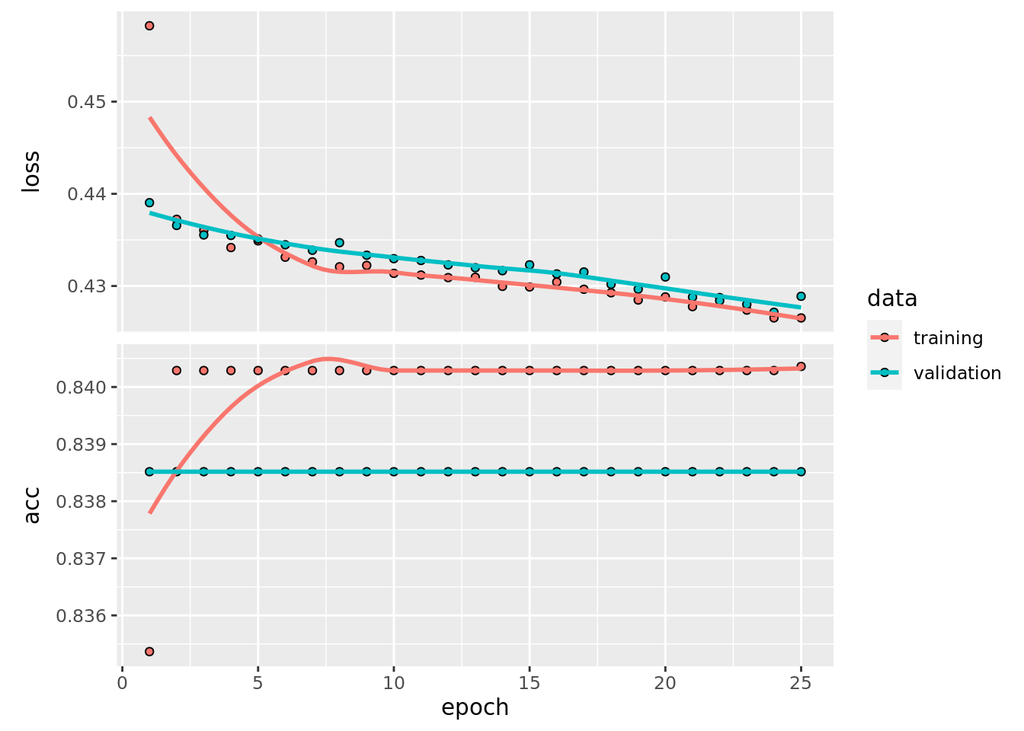

```r
## select our predictor and outcome variables
scaled_train_x <- scaled_train[, c('Length_of_stay','Admission_acuity','coPts','ED_visits_score')]
scaled_train_y <- scaled_train[, 'readmit30']

## train the model
training <- model %>% fit(x = scaled_train_x, y = scaled_train_y, validation_split = 0.20, batch_size = 100, epochs = 25)
plot(training)
```

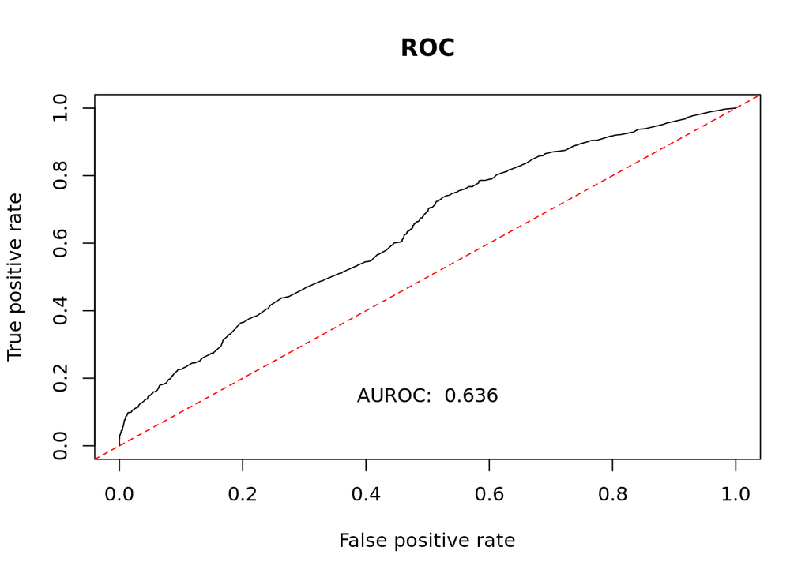

```r
## as before, we have our model make predictions on the test dataset
nn_predictions <- model %>% predict_proba(scaled_test[,c("Length_of_stay","Admission_acuity", "coPts", "ED_visits_score")])

## compare those predictions to the true class labels
nn_pr <- prediction(nn_predictions, scaled_test[,"readmit30"])

## evaluate the performance of the model
nn_perf <- performance(nn_pr, measure = "tpr", x.measure = "fpr")

## calculate the AUC of the model
nn_auc <- performance(nn_pr, measure = "auc")
nn_auc <- nn_auc@y.values[[1]]

## plot the model performance
plot(nn_perf, main="ROC")
abline(a=0, b=1, col='red', lty=2)
text(0.5, 0.15, paste('AUROC: ', round(nn_auc, 3)))
```

```r
## we can also have the neural network output the predicted class (rather than class probability)
nn_classes <- model %>% predict_classes(scaled_test[,c("Length_of_stay","Admission_acuity", "coPts", "ED_visits_score")])

## then use that as input to confusionMatrix()
nn_conf <- confusionMatrix(as.factor(nn_classes), as.factor(scaled_test[,"readmit30"]), positive = '1')
nn_conf
```

```
## Confusion Matrix and Statistics
##
##           Reference
## Prediction    0    1
##          0 3679  701
##          1    0    0
##
##                Accuracy : 0.84
##                  95% CI : (0.8288, 0.8507)
##     No Information Rate : 0.84
##     P-Value [Acc > NIR] : 0.5101
##
##                   Kappa : 0
##  Mcnemar's Test P-Value : <2e-16
##
##             Sensitivity : 0.00
##             Specificity : 1.00
##          Pos Pred Value :  NaN
##          Neg Pred Value : 0.84
##              Prevalence : 0.16
##          Detection Rate : 0.00
##    Detection Prevalence : 0.00
##       Balanced Accuracy : 0.50
##
##        'Positive' Class : 1
##
```

Sensitivity is still very very low. Again, I suspect it’s the low number of readmission cases in our data.

```r
dbDisconnect(con)
```